# Can trait patterns along gradients predict plant community responses to climate change?

#### **Figure S3.** A contoured heat map showing the alignment of model simulations to field data in terms of species composition under a broad survey of replacement rates (d) and immigration rates (m). The heat map depicts the mean difference (“Mean Deviation”) in Bray-Curtis dissimilarity of species-level composition between observed field data and 100 simulation reps for each combination of parameters. In the top right panel, solid circles show the combinations of site-level immigration and replacement rates used in null model simulations.

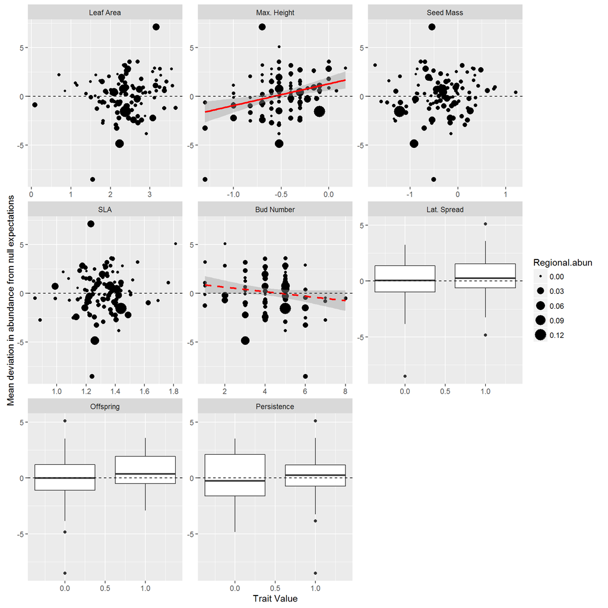

```r
# Figure S4

# summarise by spp, year, and center around zero
tmp <- simdat.spp %>%
  filter(!is.na(abun)) %>%
  group_by(sp, year) %>%
  summarise(abun = mean(abun)) %>%
  ungroup() %>%
  mutate(abun = abun - mean(abun))

# append traits and gather
tmp <- cbind(tmp, trait.data[match(tmp$sp, trait.data$species), names(traits2)])
tmp <- gather_(tmp, "trait", "value", names(traits2))

# linear models to test for trends
mods <- tmp %>%
  group_by(trait, year) %>%
  do(mod = lm(abun ~ value, data = .)) %>%
  mutate(
    pval = summary(mod)[['coefficients']][2,4],
    box = ifelse(trait %in% c('leaf.area','max.height','sla','buds','seed.mass'), 0, 1))

tmp <- cbind(tmp, mods[match(paste(tmp$trait, tmp$year), paste(mods$trait, mods$year)), c('pval','box')])
tmp$trait <- factor(traits2[match(tmp$trait, names(traits2))], traits2)

# 2013 data
tmp <- filter(tmp, year == 2013)

# Determine spp regional abundance as a measure of spp importance
regabun <- as.data.frame(colSums(cover[cover.meta$TTtreat %in% c('TTC','TT1'), ]))
regabun <- data.frame(sp = row.names(regabun), abun = regabun[,1] / sum(regabun[,1]))
tmp$Regional.abun <- regabun$abun[match(tmp$sp, regabun$sp)]

figS4 <- ggplot(tmp, aes(x = value, y = abun)) +
  geom_point(data = filter(tmp, box == 0), aes(size = Regional.abun)) +
  geom_boxplot(data = filter(tmp, box == 1), aes(group = value)) +
  stat_smooth(method = 'lm', data = filter(tmp, pval < 0.1 & pval > 0.05), lty = 2, color = 'red') +
  stat_smooth(method = 'lm', data = filter(tmp, pval < 0.05), color = 'red') +
  facet_wrap(~trait, scale = 'free') +
  geom_hline(yintercept = 0, lty = 2, color = 'black') +
  ylab("Mean deviation in abundance from null expectations") +
  xlab("Trait Value")

figS4
```

#### **Figure S4.** Differences between predicted and observed species abundances in 2013, plotted by trait value using scatterplots (continuous traits) or boxplots (binary traits). Red lines and 95% confidence intervals are shown when there are significant (solid red line) or nearly significant (dashed red line) relationships. The diameter of each solid circle is proportional to its abundance in the region.

### Print PDFs and beautified species trait data in .csv format

```r
dir.create("//MS_TraitsTransplants//figures")
setwd(paste0(wd, "//MS_TraitsTransplants//figures"))
pdf("figure2.pdf", width = 5, height = 9.5)
print(fig2)
dev.off()
```

```r
pdf("figure3.pdf", width = 6, height = 7.5)
print(fig3)
dev.off()
```

```r
pdf("figure4.pdf", width = 6, height = 7.5)
print(fig4)
dev.off()
```

```r
pdf("figureS1.pdf", width = 6, height = 5)
print(figS1)
dev.off()
```

```r
pdf("figureS2.pdf", width = 6, height = 3)
print(figS2)
dev.off()
```

```r
pdf("figureS3.pdf", width = 6, height = 3)
print(figS3)
dev.off()
```

```r
pdf("figureS4.pdf", width = 8, height = 8)
print(figS4)
dev.off()
```

```r
# write a beautified version of the trait table for supplementary materials
tmp <- plyr::ldply(strsplit(as.character(trait.data.full$species), ' '))
x <- trait.data.full[, names(traits2)]
names(x) <- traits3[match(names(x), names(traits3))]
x <- cbind(data.frame(Family = trait.data.full$family, Genus = tmp$V1,
  Species = tmp$V2), x)
x[, 4:7] <- apply(x[, 4:7], 2, function(x) format(round(as.numeric(x), 3), 3))
write.csv(x, file = 'SpeciesData.csv', row.names = F)
```